# Study4-Environment Analysis

Investigating the influence of the agent’s Environment on the Side-Effect Effect

Bradley Kennedy

# Study Information

This preregistered study was a online study conducted using Qualtrics, recruiting with Prolific.co. The study investigated how intention is viewed. That is, whether or not an action was planned. Additionally, it investigated how much particular actions deserve praise or blame.

In the study, vignettes were presented to participants. These vignettes varied the environment of the main character (agent). For example vignettes, see the OSF repository.

Preregistration, materials, analysis code and a copy of the anonymised data will be made publically available on the Open Science Framework, links below.

OSF Repository: https://osf.io/hyve2/  
OSF Preregistration: https://osf.io/7d5up

# R Set-up

Current R Version: 4.3.0

Check if required packages need to be installed, if so, install

```r
list_of_packages<-c("tidyverse","dplyr", "stringr", "ordinal", "emmeans", "Hmisc", "here")
new.packages <-
  list_of_packages[!(list_of_packages %in% installed.packages()[,"Package"])]
if(length(new.packages))install.packages(new.packages)

lapply(list_of_packages, library, character.only = TRUE)
```

Check for package updates from cloud.r-project.org

```r
update.packages(ask=FALSE, repos = "https://cloud.r-project.org")
```

Import Data & Set variables

```r
s4data <- read_csv(here("DataWrangling","cleaned_s4data.csv"), col_types =
                     cols(List = col_factor(levels = c("1", "2", "3", "4")),
                          Question = col_factor(levels = c("int", "pb")),
                          Power = col_factor(levels = c("high", "low")),
                          Environment = col_factor(levels = c("inwork", "outwork"))))

# Plot data set-up
PlotData <- s4data
PlotData$Environment <- PlotData$Environment %>%
  as.factor() %>%
  plyr::revalue(c("inwork"="In Work", "outwork"="Out Work"))
PlotData$Power <- PlotData$Power %>%
  as.factor() %>%
  plyr::revalue(c("low"="Low power", "high"="High power"))

s4data$age <- as.numeric(s4data$age)
s4data$gender <- tolower(s4data$gender)
s4data$gender <- as.factor(s4data$gender)
s4data$Job <- as.factor(s4data$Job)

# Filters for (1) Blame/Praise and (2) Intentionality for the main analysis
filterPB <- s4data$Question == "pb"
filterInt <- s4data$Question == "int"

# This creates the ordered factor for the Rating variable which is Likert scale
s4data$Rating <- as.ordered(s4data$Rating)

# Creates factors for the random effects
s4data$Participant <- as.factor(s4data$Participant)
s4data$Item <- as.factor(s4data$Item)

# This centres the fixed factors using deviation coding
contrasts(s4data$Power) <- matrix(c(.5, -.5))
contrasts(s4data$Environment) <- matrix(c(.5, -.5))
```

# Demographics

```r
# Report N
s4data_n <- length(unique(s4data$Participant))

# Report Mean and SD completion times
mean_time <-  round(mean(s4data$Duration)/60, digits = 2)
sd_time <- round(sd(s4data$Duration)/60, digits = 2)
median_time <- round(median(s4data$Duration)/60, digits = 2)

# Report Gender
# Capitalise each value to avoid interaction of "man" and "woman" in str_detect
# check for unique elements in `gender`
s4data$gender <- str_to_title(s4data$gender)
unique_genders <- unique(s4data$gender)
# define pattern for each category
Male <- paste(c("Male", "Man", "M"), collapse = "|")
Female <- paste(c("Female", "Woman", "F"), collapse = "|")
Non_binary <- paste(c("Other", "Mtf", "Ftm", "Non-binary"), collapse= "|")

# apply category with `case_when` and pattern:
s4data <- s4data %>%
    mutate(gender = case_when(
        str_detect(gender, Male) ~ "Male",
        str_detect(gender, Female) ~ "Female",
        str_detect(gender, Non_binary) ~ "Non-binary"))

pp_gender <- s4data %>%
  group_by(gender) %>%
  dplyr::summarise(gender_count = n() / (count(s4data)/length(unique(s4data$Participant))))

# M SD Min Max Age
pp_age <- summary(s4data$age)
pp_sd_age <- round(sd(s4data$age), digits = 2)
```

N = 205  
Mean (SD) Time to complete: 22.09 (10.63)  
Median Time to complete: 18.85  
Gender Summary

```
## # A tibble: 2 × 2
##   gender gender_count$n
##   <chr>           <dbl>
## 1 Female             93
## 2 Male              112
```

Age Summary

```
##    Min. 1st Qu.  Median    Mean 3rd Qu.    Max.
##   21.00   31.00   38.00   40.34   47.00   75.00
```

SD Age: 12.28

# Analysis

## Cumulative Link Mixed Models

Christensen, R. H. B. (2019). ordinal - Regression Models for Ordinal Data. R package version 2019.12-10. https://CRAN.R-project.org/package=ordinal.

### Blame model

DV is `Rating` which is the Likert scale response of assigning degree of Blame (0 to 6) `Power` is the Agent’s Job Power level experimental factor (levels high & low) `Environment` is the In-Work / Out-Work experimental factor (level inwork = In-Work; level outwork = Out-Work)

```r
PB_Model <- clmm(Rating ~ Power * Environment + (1 + Power * Environment | Participant) +
                   (1 + Power * Environment | Item), data = s4data[filterPB,])
summary(PB_Model)
```

```
## Cumulative Link Mixed Model fitted with the Laplace approximation
##
## formula:
## Rating ~ Power * Environment + (1 + Power * Environment | Participant) +
##     (1 + Power * Environment | Item)
## data:    s4data[filterPB, ]
##
##  link  threshold nobs logLik    AIC      niter       max.grad cond.H
##  logit flexible  6560 -10911.42 21880.85 6185(44443) 5.07e-03 1.1e+03
##
## Random effects:
##  Groups      Name                        Variance  Std.Dev. Corr
##  Participant (Intercept)                 1.7815835 1.33476
##              Powerlow                    0.1763987 0.42000  -0.388
##              Environmentoutwork          0.4806813 0.69331  -0.105  0.439
##              Powerlow:Environmentoutwork 0.0819579 0.28628   0.404 -0.951
##  Item        (Intercept)                 0.7593104 0.87138
##              Powerlow                    0.0138739 0.11779  -0.060
##              Environmentoutwork          0.8710536 0.93330  -0.448  0.180
##              Powerlow:Environmentoutwork 0.0006212 0.02492  -0.069 -0.843
##
##
##
##
##  -0.141
##
##
##
##   0.362
## Number of groups:  Participant 205,  Item 32
##
## Coefficients:
##                     Estimate Std. Error z value Pr(>|z|)
## Power1               0.16412    0.05308   3.092  0.00199 **
## Environment1         0.57258    0.17871   3.204  0.00136 **
## Power1:Environment1 -0.09915    0.09267  -1.070  0.28468
## ---
## Signif. codes:  0 '***' 0.001 '**' 0.01 '*' 0.05 '.' 0.1 ' ' 1
##
## Threshold coefficients:
##     Estimate Std. Error z value
## 0|1  -3.5536     0.1777 -19.997
## 1|2  -2.1816     0.1722 -12.668
## 2|3  -1.1891     0.1704  -6.977
## 3|4  -0.5050     0.1699  -2.973
## 4|5   0.6356     0.1699   3.741
## 5|6   2.0540     0.1717  11.961
```

```r
# This produces the pairwise comparisons in the Blame Model for the interaction of Agent Power (Power) and Agent Environment (Environment)
emmeans(PB_Model, pairwise ~ Power * Environment, adjust = "none")
```

```
## $emmeans
##  Power Environment emmean    SE  df asymp.LCL asymp.UCL
##  high  inwork       1.134 0.186 Inf   0.76837     1.499
##  low   inwork       1.019 0.183 Inf   0.66087     1.377
##  high  outwork      0.611 0.201 Inf   0.21645     1.005
##  low   outwork      0.397 0.206 Inf  -0.00717     0.801
##
## Confidence level used: 0.95
##
## $contrasts
##  contrast                   estimate     SE  df z.ratio p.value
##  high inwork - low inwork      0.115 0.0732 Inf   1.564  0.1178
##  high inwork - high outwork    0.523 0.1838 Inf   2.846  0.0044
##  high inwork - low outwork     0.737 0.1924 Inf   3.829  0.0001
##  low inwork - high outwork     0.408 0.1803 Inf   2.266  0.0235
##  low inwork - low outwork      0.622 0.1854 Inf   3.355  0.0008
##  high outwork - low outwork    0.214 0.0676 Inf   3.162  0.0016
```

```r
# This produces the confidence intervals for the main effects and the interaction for the Blame Model
confint(PB_Model)
```

```
##                           2.5 %      97.5 %
## 0|1                 -3.90193656 -3.20533249
## 1|2                 -2.51916576 -1.84410675
## 2|3                 -1.52321054 -0.85507802
## 3|4                 -0.83795840 -0.17202998
## 4|5                  0.30255641  0.96857986
## 5|6                  1.71742830  2.39055260
## Power1               0.06007761  0.26816665
## Environment1         0.22230590  0.92284752
## Power1:Environment1 -0.28078336  0.08248802
```

### Intentionality model

DV is `Rating` which is the Likert scale response of assigning degree of Intentionality (0 to 6) `Power` is the Agent’s Job Power level experimental factor (levels high & low) `Environment` is the In-Work / Out-Work experimental factor (level inwork = In-Work; level outwork = Out-Work)

```r
Int_Model <- clmm(Rating ~ Power * Environment + (1 + Power * Environment | Participant) +
                    (1 + Power * Environment | Item), data = s4data[filterInt,])

summary(Int_Model)
```

```
## Cumulative Link Mixed Model fitted with the Laplace approximation
##
## formula:
## Rating ~ Power * Environment + (1 + Power * Environment | Participant) +
##     (1 + Power * Environment | Item)
## data:    s4data[filterInt, ]
##
##  link  threshold nobs logLik    AIC      niter       max.grad cond.H
##  logit flexible  6560 -10576.08 21210.16 5846(41356) 7.24e-03 1.2e+03
##
## Random effects:
##  Groups      Name                        Variance Std.Dev. Corr
##  Participant (Intercept)                 3.054732 1.74778
##              Powerlow                    0.144837 0.38057  -0.458
##              Environmentoutwork          0.324493 0.56964  -0.059  0.130
##              Powerlow:Environmentoutwork 0.063206 0.25141   0.446 -0.617  0.678
##  Item        (Intercept)                 0.592357 0.76965
##              Powerlow                    0.009664 0.09831  -0.025
##              Environmentoutwork          0.715761 0.84603  -0.430 -0.143
##              Powerlow:Environmentoutwork 0.004818 0.06941  -0.351  0.940 -0.078
##
##
##
##
##
##
##
##
##
## Number of groups:  Participant 205,  Item 32
##
## Coefficients:
##                     Estimate Std. Error z value Pr(>|z|)
## Power1               0.07139    0.05558   1.284   0.1990
## Environment1         0.52039    0.16287   3.195   0.0014 **
## Power1:Environment1 -0.17254    0.09288  -1.858   0.0632 .
## ---
## Signif. codes:  0 '***' 0.001 '**' 0.01 '*' 0.05 '.' 0.1 ' ' 1
##
## Threshold coefficients:
##     Estimate Std. Error z value
## 0|1  -3.7993     0.1826 -20.807
## 1|2  -2.2039     0.1763 -12.501
## 2|3  -0.9096     0.1743  -5.219
## 3|4  -0.1998     0.1739  -1.149
## 4|5   1.1890     0.1745   6.815
## 5|6   2.7829     0.1776  15.667
```

```r
# This produces the pairwise comparisons for the Intentionality Model for the interaction of Agent Job Power (Power) and Agent Environment (Environment)
emmeans(Int_Model, pairwise ~ Power * Environment, adjust = "none")
```

```
## $emmeans
##  Power Environment emmean    SE  df asymp.LCL asymp.UCL
##  high  inwork       0.776 0.189 Inf    0.4065     1.146
##  low   inwork       0.791 0.183 Inf    0.4326     1.150
##  high  outwork      0.342 0.204 Inf   -0.0571     0.741
##  low   outwork      0.184 0.201 Inf   -0.2105     0.579
##
## Confidence level used: 0.95
##
## $contrasts
##  contrast                   estimate     SE  df z.ratio p.value
##  high inwork - low inwork    -0.0149 0.0709 Inf  -0.210  0.8337
##  high inwork - high outwork   0.4341 0.1678 Inf   2.588  0.0097
##  high inwork - low outwork    0.5918 0.1722 Inf   3.436  0.0006
##  low inwork - high outwork    0.4490 0.1720 Inf   2.611  0.0090
##  low inwork - low outwork     0.6067 0.1709 Inf   3.549  0.0004
##  high outwork - low outwork   0.1577 0.0740 Inf   2.132  0.0330
```

```r
# This produces the confidence intervals for the main effects and the interaction for the Intentionality Model
confint(Int_Model)
```

```
##                           2.5 %      97.5 %
## 0|1                 -4.15716503 -3.44140426
## 1|2                 -2.54947873 -1.85838224
## 2|3                 -1.25127788 -0.56799978
## 3|4                 -0.54072828  0.14110081
## 4|5                  0.84703368  1.53096175
## 5|6                  2.43476437  3.13107959
## Power1              -0.03755214  0.18033403
## Environment1         0.20116967  0.83961300
## Power1:Environment1 -0.35457503  0.00948941
```

### Null model comparisons

```r
PB_null <- clmm(Rating ~ 1 + (1 + Power * Environment | Participant) +
                  (1 + Power * Environment | Item),
                data = s4data[filterPB,])

Int_null <- clmm(Rating ~ 1 + (1 + Power * Environment | Participant) +
                   (1 + Power * Environment | Item),
                 data = s4data[filterInt,])

# Comparisons with null models
anova(PB_null, PB_Model)
```

```
## Likelihood ratio tests of cumulative link models:
##
##          formula:
## PB_null  Rating ~ 1 + (1 + Power * Environment | Participant) + (1 + Power * Environment | Item)
## PB_Model Rating ~ Power * Environment + (1 + Power * Environment | Participant) + (1 + Power * Environment | Item)
##          link: threshold:
## PB_null  logit flexible
## PB_Model logit flexible
##
##          no.par   AIC logLik LR.stat df Pr(>Chisq)
## PB_null      26 21890 -10919
## PB_Model     29 21881 -10911   15.45  3    0.00147 **
## ---
## Signif. codes:  0 '***' 0.001 '**' 0.01 '*' 0.05 '.' 0.1 ' ' 1
```

```r
anova(Int_null, Int_Model)
```

```
## Likelihood ratio tests of cumulative link models:
##
##           formula:
## Int_null  Rating ~ 1 + (1 + Power * Environment | Participant) + (1 + Power * Environment | Item)
## Int_Model Rating ~ Power * Environment + (1 + Power * Environment | Participant) + (1 + Power * Environment | Item)
##           link: threshold:
## Int_null  logit flexible
## Int_Model logit flexible
##
##           no.par   AIC logLik LR.stat df Pr(>Chisq)
## Int_null      26 21217 -10582
## Int_Model     29 21210 -10576  12.486  3   0.005891 **
## ---
## Signif. codes:  0 '***' 0.001 '**' 0.01 '*' 0.05 '.' 0.1 ' ' 1
```

### Main effect models

Models showing the main effects of agent power and the environment only (but no interaction) for each of Blame and then Intentionality. Each model is immediately followed by a comparison of the main-effects only model with the final model (that includes the interaction).

```r
PB_Model_main <- clmm(Rating ~ Power + Environment +
                        (1 + Power + Environment | Participant) +
                   (1 + Power + Environment | Item), data = s4data[filterPB,])

summary(PB_Model_main)
```

```
## Cumulative Link Mixed Model fitted with the Laplace approximation
##
## formula:
## Rating ~ Power + Environment + (1 + Power + Environment | Participant) +
##     (1 + Power + Environment | Item)
## data:    s4data[filterPB, ]
##
##  link  threshold nobs logLik    AIC      niter       max.grad cond.H
##  logit flexible  6560 -10913.46 21866.91 3609(26308) 4.39e-03 8.5e+02
##
## Random effects:
##  Groups      Name               Variance Std.Dev. Corr
##  Participant (Intercept)        1.70394  1.3054
##              Powerlow           0.07024  0.2650   -0.345
##              Environmentoutwork 0.47300  0.6878   -0.027  0.428
##  Item        (Intercept)        0.75511  0.8690
##              Powerlow           0.01205  0.1098   -0.060
##              Environmentoutwork 0.87460  0.9352   -0.447  0.221
## Number of groups:  Participant 205,  Item 32
##
## Coefficients:
##              Estimate Std. Error z value Pr(>|z|)
## Power1        0.16356    0.05262   3.108  0.00188 **
## Environment1  0.57065    0.17825   3.201  0.00137 **
## ---
## Signif. codes:  0 '***' 0.001 '**' 0.01 '*' 0.05 '.' 0.1 ' ' 1
##
## Threshold coefficients:
##     Estimate Std. Error z value
## 0|1  -3.5487     0.1774 -19.999
## 1|2  -2.1783     0.1719 -12.670
## 2|3  -1.1873     0.1702  -6.978
## 3|4  -0.5045     0.1696  -2.975
## 4|5   0.6337     0.1696   3.736
## 5|6   2.0497     0.1714  11.956
```

```r
anova(PB_Model_main, PB_Model)
```

```
## Likelihood ratio tests of cumulative link models:
##
##               formula:
## PB_Model_main Rating ~ Power + Environment + (1 + Power + Environment | Participant) + (1 + Power + Environment | Item)
## PB_Model      Rating ~ Power * Environment + (1 + Power * Environment | Participant) + (1 + Power * Environment | Item)
##               link: threshold:
## PB_Model_main logit flexible
## PB_Model      logit flexible
##
##               no.par   AIC logLik LR.stat df Pr(>Chisq)
## PB_Model_main     20 21867 -10913
## PB_Model          29 21881 -10911  4.0635  9     0.9072
```

```r
Int_Model_main <- clmm(Rating ~ Power + Environment +
                         (1 + Power + Environment | Participant) +
                    (1 + Power + Environment | Item), data = s4data[filterInt,])

summary(Int_Model_main)
```

```
## Cumulative Link Mixed Model fitted with the Laplace approximation
##
## formula:
## Rating ~ Power + Environment + (1 + Power + Environment | Participant) +
##     (1 + Power + Environment | Item)
## data:    s4data[filterInt, ]
##
##  link  threshold nobs logLik    AIC      niter       max.grad cond.H
##  logit flexible  6560 -10580.04 21200.07 3562(25349) 6.74e-03 6.7e+02
##
## Random effects:
##  Groups      Name               Variance Std.Dev. Corr
##  Participant (Intercept)        2.96120  1.7208
##              Powerlow           0.10031  0.3167   -0.383
##              Environmentoutwork 0.43861  0.6623    0.008  0.292
##  Item        (Intercept)        0.59968  0.7744
##              Powerlow           0.01632  0.1277   -0.129
##              Environmentoutwork 0.70873  0.8419   -0.438 -0.090
## Number of groups:  Participant 205,  Item 32
##
## Coefficients:
##              Estimate Std. Error z value Pr(>|z|)
## Power1        0.06965    0.05523   1.261  0.20725
## Environment1  0.51959    0.16249   3.198  0.00138 **
## ---
## Signif. codes:  0 '***' 0.001 '**' 0.01 '*' 0.05 '.' 0.1 ' ' 1
##
## Threshold coefficients:
##     Estimate Std. Error z value
## 0|1  -3.7959     0.1824 -20.811
## 1|2  -2.2024     0.1761 -12.506
## 2|3  -0.9089     0.1741  -5.220
## 3|4  -0.2002     0.1737  -1.152
## 4|5   1.1868     0.1743   6.810
## 5|6   2.7788     0.1774  15.662
```

```r
anova(Int_Model_main, Int_Model)
```

```
## Likelihood ratio tests of cumulative link models:
##
##                formula:
## Int_Model_main Rating ~ Power + Environment + (1 + Power + Environment | Participant) + (1 + Power + Environment | Item)
## Int_Model      Rating ~ Power * Environment + (1 + Power * Environment | Participant) + (1 + Power * Environment | Item)
##                link: threshold:
## Int_Model_main logit flexible
## Int_Model      logit flexible
##
##                no.par   AIC logLik LR.stat df Pr(>Chisq)
## Int_Model_main     20 21200 -10580
## Int_Model          29 21210 -10576  7.9057  9     0.5437
```

### Plots

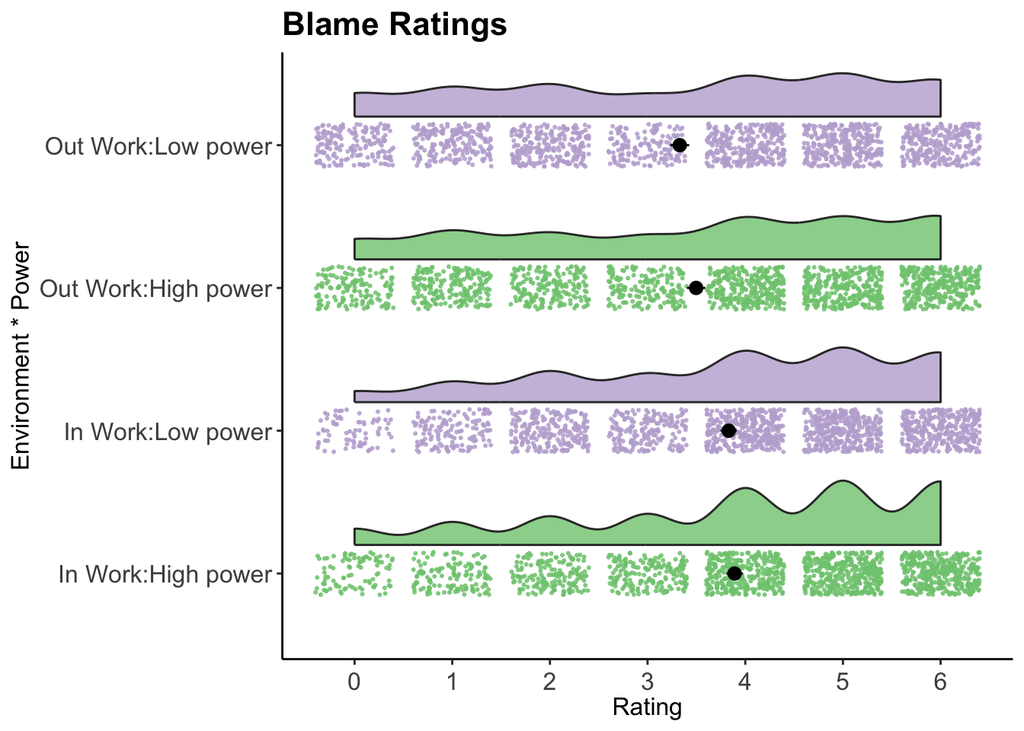

```r
# These two lines create the filters for (1) Blame/Praise and (2) Intentionality for plotting
filterPB2 <-PlotData$Question == "pb"
filterInt2 <-PlotData$Question == "int"

# This is the code for the raincloud plots
source("https://gist.githubusercontent.com/benmarwick/2a1bb0133ff568cbe28d/raw/fb53bd97121f7f9ce947837ef1a4c65a73bffb3f/geom_flat_violin.R")
raincloud_theme = theme(text = element_text(size = 12), axis.title.x = element_text(size = 12),
                        axis.title.y = element_text(size = 12), axis.text = element_text(size = 12),
                        axis.text.x = element_text(vjust = 0.5), legend.title = element_text(size = 12),
                        legend.text = element_text(size=12), legend.position = "right",
                        plot.title = element_text(lineheight=.8, face = "bold", size = 16),
                        panel.border = element_blank(), panel.grid.minor = element_blank(),
                        panel.grid.major = element_blank(),
                        axis.line.x = element_line(colour = 'black', size = 0.5, linetype = 'solid'),
                        axis.line.y = element_line(colour = 'black', size = 0.5, linetype = 'solid'))

# This is the code to create the raincloud plot for the Blame data
PBRain <- ggplot(data = PlotData[filterPB2,],
                 aes(y = Rating, x = PlotData[filterPB2,]$Environment : PlotData[filterPB2,]$Power,
                     fill = Power)) +
  geom_flat_violin(position = position_nudge(x = .2, y = 0), alpha = .8, trim=TRUE) +
  geom_point(aes(y = Rating, color = Power),
             position = position_jitter(width = .15), size = .4, alpha = 0.8) +
  expand_limits(x = 3) +
  guides(fill = FALSE) +
  guides(color = FALSE) +
  scale_color_brewer(palette = "Accent") +
  scale_fill_brewer(palette = "Accent") +
  coord_flip() + theme_bw() +
  raincloud_theme +
  labs(x = "Environment * Power", title = "Blame Ratings") +
  scale_y_continuous(breaks = seq(0,6,by = 1)) +
  stat_summary(fun.data = "mean_cl_boot", colour = "black", size = .5)

PBRain
```

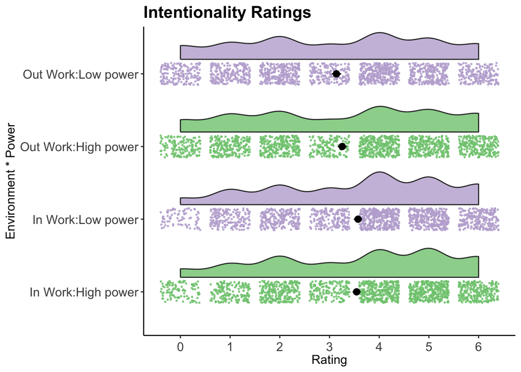

```r
# This is the raincloud plot for the Intentionality model
IntRain <- ggplot(data = PlotData[filterInt2,],
                 aes(y = Rating, x = PlotData[filterInt2,]$Environment : PlotData[filterInt2,]$Power, fill = Power)) +
  geom_flat_violin(position = position_nudge(x = .2, y = 0), alpha = .8, trim=TRUE) +
  geom_point(aes(y = Rating, color = Power),
             position = position_jitter(width = .15), size = .4, alpha = 0.8) +
  expand_limits(x = 3) +
  guides(fill = FALSE) +
  guides(color = FALSE) +
  scale_color_brewer(palette = "Accent") +
  scale_fill_brewer(palette = "Accent") +
  coord_flip() +
  theme_bw() +
  raincloud_theme +
  labs(x = "Environment * Power", title = "Intentionality Ratings") +
  scale_y_continuous(breaks = seq(0,6,by = 1)) +
  stat_summary(fun.data = "mean_cl_boot", colour = "black", size =.5)

IntRain
```

# Research Team

This research was conducted by [Bradley Kennedy](https://bradk.co.uk)  
Principal Supervisor: Dr Suzanne L. K. Stewart  
Supervision Team: Dr Annie Scudds & Professor Moira Lafferty